# Continuous Time Markov Rate Modeling on R

David J. Silkworth

2024-04-12

Markov models often referred to as Markov chains are ubiquitous in the world of statistical analysis. In most Markov systems states are defined to describe the system status. A fundamental principle of a Markov process is that the system will transition from one state to another strictly on some probabilistic basis, without knowledge or concern of any previous history. This excludes some forms of potential analysis, but renders a structured system of modeling that has proven useful in many cases.

For reliability and safety analysis a special case of the semi-Markov process introduced in 1954 by Paul Levy is employed. This application of Markov modeling considers the transitions from state to state occurring on the basis of constant rates, exponentially random. Commonly transitions occur from some working state to some form of failure state (either partial or complete). Correspondingly, but not always, a repair transition can move the state back to a more complete operational status.

Rate modeling has also been used in some queuing processes. The rates of interest in such cases may be arrivals to the queue and dispatch rates from the queue. The states would likely regard the size or content of the queue.

While there are many scholarly books and papers on Markov modeling theory with mesmerizing equations and formulas this is not the intent of this discussion. Rather it is desired to bring the technique to a potential analyst in a more intuitive way.

A tool for such presentation has been introduced in “Modeling for Reliability Analysis” by Jan and Paul Pukite. Unfortunately, the computer application presented in that work, CARMS, was written for the 16-bit Windows 3.1 operating system. In collaboration with Paul Pukite an emulation of this application has been prepared to run on the cross-platform environment developed by the R Project for Statistical Computing, or R for short. The R environment is continuously developed such that it can be reasonably anticipated that a package written for this environment will survive future evolution of computer architectures and operating systems.

### The CARMS way

The philosophy of user interaction with CARMS is to generate a graphic depiction of the system states and draw connecting arrow notated lines, often arcs, indicating transitions. The transitions are assigned rate values, often as multiples or combination of base element rates. The user can specify a method of solution for the system model. The software generates the applicable matrix representing the partial differential equations defined by the transitions and computes a solution by integration. Then a plot can be displayed of the history of state probabilities over a given mission time.

An example here could be worth a thousand words. The earliest simple example provided in “Modeling for Reliability Analysis” is entitled jeep. This example actually presents two separate models on one diagram and analysis. The first model represents a vehicle with 4 tires. Regardless of wear there is assumed to be a constant risk of tire failure, represented by a rate of failure per mile. In this simple model failed tires are neither fixed nor replaced, so the probability of being stranded with only 3 operable tires is 1-exp(-failure_rate * time). Correspondingly the probability of having a jeep with all 4 tires operable over time is easily anticipated to be exp(-failure_rate * time).

Now, the second model assumes that a spare is available, such that it is immediately used upon failure of any one original tire. However, the spare is perhaps just a doughnut and has a higher fail rate.

The diagram for these two models is depicted as:

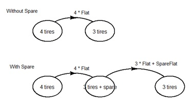

The resultant plot of the solutions is:

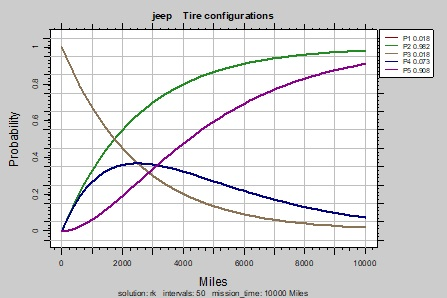

It is not as easy to see how one could model the second case in a spreadsheet where the probability of operating on 3 original tires and one spare initially increases, but ultimately declines due to the failures of either one of the original 3 tires or the spare. This delays the case where one is stranded with only 3 operable tires. The answer to this dilemma is that the second case must be integrated simultaneously through a series of integration intervals.

The original CARMS application aimed to largely obscure the details of differential equation integration and produce graphical results from a user generated diagram of the Markov model with rate data added.

### The CARMS package

The functionality of the original CARMS application has now been emulated in a package for operation on the R platform. This brings CARMS to life on today’s operating systems in a cross-platform way. Windows, Unix-like, and MacOS systems can all run this tool as if a native application. It is necessary for a user to install the R system in order to use the CARMS package. However, it is not necessary to learn R programming to use it. Instructions for installing R are provided on the R web site https://www.r-project.org/.

Once R has been installed on Windows, a rather terse window will open called the console, it is actually a program named Rgui. From there it is simple to select through menu items for Packages->Install package(s), selecting a mirror (just as you did for the R installation itself) then scrolling down to CARMS.

This installation is only performed once on a freshly installed R system. However, on every start of a new R instance it is necessary to load the library into memory with the simple command library(CARMS) onto the console.

```r
library(CARMS)
```

[ This writing has quickly become a Windows specific discussion. There are significant differences while running under Linux or MacOS. Only Windows has the Rgui.exe program to use as a console. On Linux (and assumed also for MacOS) in its raw form R is an executable that opens in the terminal. This is not as friendly a place to operate due to extreme terseness (no menus, and poor line editing). For this reason, many users then opt for an application named RStudio. While this application provides a Console pane, it also has a lot more things going on that would take more time to discuss here. ]

Now with the simple command demo(jeep) the initial example is displayed. Yes, annoyingly it takes a few presses of the Enter key to complete.

An entire library of examples is also available. The command examples() will list them. Any of the examples can be run by either calling the examples function with the number of the example as a second argument after “run”. A command of examples(“run”, 1)will run the jeep example again, but all at once. It is also possible to copy an example name as an argument inside quotation marks such as

```r
examples("run", "48_PerCPUIO.R")
```

### CARMS object development and diagram building

It has been said that “everything in R is an object”. In the case of this CARMS emulation the information defining each model is stored in a carms object. The carms object for any model is generated through execution of a series of script lines. These script lines can be written on any text editor and will usually be saved with the .R suffix. This is the method of persistence for all examples that have been prepared.

The first script line command for forming a carms object is unsurprisingly carms.make. One always gives an object name, the make.carms function must also be given a title, which will be used to annotate its eventual plot.

```r
Pa2Simpl<-carms.make(title="Parallel        Same failure rates", diagram_grid=c(9,13))
```

This line will establish an initial carms object named Pa2Simpl modeling 2 elements functioning in parallel. It is also defining a grid system for the diagram that has 9 rows and 13 columns. This grid is applied to whatever output plot size may eventually be defined.

Now to place a first state on the diagram the cams.state function is used. The object building functions after carms.make all progressively modify the carms object in memory. So the object name is used as the result of the function that will act on the formative object provided as a first argument.

```r
Pa2Simpl<- carms.state(Pa2Simpl, prob=1.0, name="2 good", size=7, h2w=14/20, position=c(3,5) )
```

The next two states in this simple example are added to the carms object with similar script lines.

```r
Pa2Simpl<-carms.state(Pa2Simpl, prob=0, name="1 failed", size=7, h2w=14/20, position=c(7,5) )
Pa2Simpl<-carms.state(Pa2Simpl, prob=0, name="2 failed", size=7, h2w=14/20, position=c(11,5) )
```

These next states will be placed on the diagram progressively moving to the right along the center of the diagram. Of course the initial state probabilities for these subsequent states is zero. Once any state lines have been added to the R script it is possible to get a preliminary view of the formative diagram simply calling

```r
diagram(Pa2Simpl)
```

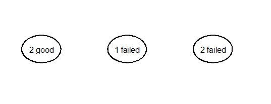

As a diagram is being developed it is common to make several views of the diagram for trial and modification activity. One could say his makes diagram building semi-interactive.

It is also possible to view the way that the carms object is stored in memory by simply typing its name in the console. The carms object is a list construct which is basic to R. It should be noted here that the state names given in carms.state command lines are simply those that will appear on the diagram. Internally the carms object identifies the states numerically in the order they were entered. This can be seen in the list object Pa2Simpl$state where the state numbers are enclosed in double brackets.

```r
Pa2Simpl$state
```

[output not shown]

### State transition definitions

Transitions are comprised of a directional sequence (from, to) and a numeric rate. Often rates are defined by multiples or combinations of some base elements. For this reason, CARMS provides a mechanism for storing such base element rates. This is done using the carms.base function. As with carms.state the carms.base function adds information to the carms object, so its result is returned to the carms object name and the first argument is the carms object as so far developed. In this first simple example there is only one base element, and one might think this step could be dispensed with, however it is the only location to indicate the units of time used for the model and must be provided.

```r
Pa2Simpl<-carms.base(Pa2Simpl, value=1.0, time_units="hours")
```

The value of this base rate is later retrievable using lables B1, or b1 because this was the first base value entered. Subsequent base values will be retrievable using lables B2, B3 (or b2, b3) etcetera. It is also possible to identify any base value with a particular base_label entered as a string argument.

With this base value specified it is now possible to complete the definition of the transitions in this simple model.

```r
Pa2Simpl<-carms.arrow(Pa2Simpl, from=1, to=2, rate="2*B1", arc=.35, label="2 * B1")
Pa2Simpl<-carms.arrow(Pa2Simpl, from=2, to=3, rate="B1", arc=.35, label="B1")
```

Consistent with the apparent nomenclature from the original CARMS application transitions are defined using the carms.arrow function. Using a familiar technique of passing in the developing carms object as first argument continues. It is instructive to note that although the rate and label are the same in this example this is not always the case. The label string is the notation that will be provided on the diagram.

Again by calling diagram(Pa2Simple) the effect of the specification for the transition arrow(s) can be viewed and modified as found pleasing through perhaps several trials.

```r
diagram(Pa2Simpl)
```

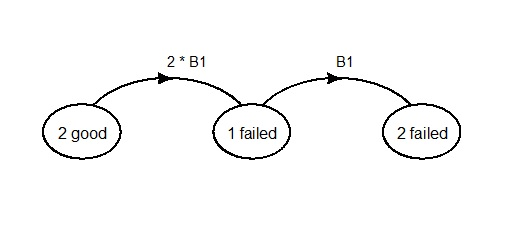

With a model completely defined as has been done here, it is possible to run a simulation on the model.

### Implementing a solution

Three methods of integrating the rate defined model over mission time are provided. The 4th order Runge-Kutta method is often specified, but can fail if the model is “too tight”. Unfortunately, no one has provided a definition as to what makes a model “too tight”.Suffice it to say some Runge-Kutta results make no sense. For this reason, a second analytic method, the backward difference method is also provided. Thirdly, a stochastic method is provided to develop the chain over numerous randomized cycles through the mission time. The original CARMS application developed this “chained” method using a Petri Net formalism. The stochastic chain method provided in the CARMS package provides the same result but takes advantage of the fact that all transitions are defined by rates. Due to high cycling, typically in the thousands of iterations, the stochastic method would be expected to take more time. However, by coding this in compiled C++ code most models can be resolved with little apparent delay.

The analytic methods in the CARMS package are implementations of algorithms presented by William Stewart in “Introduction to the Numerical Solution of Markov Chains”. The stochastic chain algorithm was developed independently similar to methods used in R package stosim. For interested users the original development of this algorithm in slow interpreted R code is also provided as a basis for study. This working code can also be specified for any specific model. The four solution arguments are “rk”, “bd”, “chain”, and “chain_R”. Each solution method requires a mission time and a number of time intervals for evaluation. A default of 50 intervals seems adequate for most models. The chained method requires a specification for the number of cycles; 2000 is provided as a default. Some model results provide more pleading curves with increased cycling.

Once a carms object has been fully defined any call to the simulate function can be made. The result of simulation is a matrix of probabilities fore each state at each interval. This matrix is added to the carms object in the same manner that all other model elements were. Subsequent calls to simulate on the same carms object will replace the simulation matrix with the last requested result.

```r
Pa2Simpl<-simulate.carms(Pa2Simpl, solution="rk", mission_time=5, intervals=50)
```

With a simulation provided to the carms object, the final step is to display a plotted result.

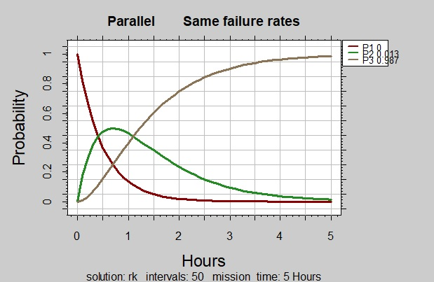

```r
plot(Pa2Simpl)
```